# Week1 Homework

Author: Laura Wooten

Date: 08 April 2025

**1. Using no other R functions besides sqrt (e.g. to calculate sum use a loop summing all elements from first to last) implement function my.sd calculating standard deviation for a numeric vector of arbitrary length and demonstrate that it produces exactly the same results as R function sd.**

Steps:  
- create function  
- check for NAs  
- find mean  
- find deviation for each data point (datapoint - mean)  
- square each deviation  
- find mean of pooled deviations (when calculating use len -1) = variance  
- sqrt the variance  
- test to compare to the std function

```r
my.sd <- function(x, rm.na = T) {
  x.clean <- c() #initiate clean vector - without NAs
  x.sum <- 0
  x.len <- 0
  for (xx in x) {
    if (is.na(xx)) { #check for NAs
      if (rm.na) {
        next
      } else {
        return (NA)
      }
    }
    x.clean <- c(x.clean, xx)
    x.sum <- x.sum + xx #sum of all non na values
    x.len <- x.len +1 # find length of vector minus NAs
  }
  x.mean <- x.sum / x.len
  x.devsq <- (x.clean -x.mean)^2 #subtract mean from each value in vector and square

  x.devsq.sum <- 0
  for (xd in x.devsq) x.devsq.sum <- x.devsq.sum + xd

  x.var = x.devsq.sum / (x.len -1) #-1 for sample sd
  x.std <- sqrt(x.var)

  #list(x.clean, x.len, x.sum, x.mean, x.devsq, x.devsq.sum, x.var, x.std)
  x.std
}

v <- c(1,2,4,9, NA)
my.sd(v)
```

```
[1] 3.559026
```

```r
sd(v, na.rm=T)
```

```
[1] 3.559026
```

**2.Execute and explain the results of the following three pieces of R code. For each of them – start R afresh, copy and paste code in R command prompt. Explain in detail what the code does, what is printed (or not printed) and why.**  
**a.**

```r
x<-sin(1);print(x);y<-Sin(2);print(y)
x<-sin(1)
print(x)
y<-Sin(2)
print(y)
```

When executed:

```r
x<-sin(1);print(x);y<-Sin(2);print(y)
```

```
[1] 0.841471
```

```
Error in Sin(2) : could not find function "Sin"
```

```r
x<-sin(1)
print(x)
```

```
[1] 0.841471
```

```r
y<-Sin(2)
```

```
Error in Sin(2) : could not find function "Sin"
```

```r
print(y)
```

```
Error: object 'y' not found
```

This code takes the sin of 1, assigns it to the variable x, prints it to the screen then calls an error. This error occurs in the assignment of Sin(2) to variable y. the correct function is sin() not Sin() and this typo has therefore stalled the rest of the code from running. Looking at the remainder of this code, the 1st line completes the same task as lines 2-5 put together, it has just been condensed into 1 line as `;` can be used to separate commands.

**b.**

```r
m <- matrix(c(1:5,NA,7,7,NA),
nrow=3,ncol=3,byrow=T)
print(m)
for ( i in 1:dim(m)[[1]] ) {
 mm <- sort(m[i,],na.last=c(NA,NA,T)[[i]])
 for ( j in 1:(length(mm)-1) ) {
 if ( mm[[j]]==mm[[j+1]] ) {
 cat(i,j,mm[[j]],fill=T)
 }
 }
}
```

When executed:

```r
m <- matrix(c(1:5,NA,7,7,NA),
nrow=3,ncol=3,byrow=T)
print(m)
```

```
     [,1] [,2] [,3]
[1,]    1    2    3
[2,]    4    5   NA
[3,]    7    7   NA
```

```r
for ( i in 1:dim(m)[[1]] ) {
 mm <- sort(m[i,],na.last=c(NA,NA,T)[[i]])
 for ( j in 1:(length(mm)-1) ) {
 if ( mm[[j]]==mm[[j+1]] ) {
 cat(i,j,mm[[j]],fill=T)
 }
 }
}
```

```
3 1 7
```

```
Error in if (mm[[j]] == mm[[j + 1]]) { :
  missing value where TRUE/FALSE needed
```

Tough one to get my head around. What I believe the code is supposed to do is creating a 3x3 matrix from the vector of values and inputting it into the matrix by rows. It then goes into a outer for loop that iterates over each row (as diam() results in row x column and we select the 1st of the two with [[1]]). For each row it attempts to sort the values in ascending order and includes the na.last argument which dictates how to handle NA values in the vector. Per the help page, “If TRUE, missing values in the data are put last; if FALSE, they are put first; if NA, they are removed”. A vector of (NA,NA,TRUE)[[i]] is passed into the na.last argument indicating that for the first and second rows na.last = NA (so NAs are removed from the row when sorted), and the third row na.last = True (NA is put last in the vector after sorting). Moving to the inner loop, which iterates over the values in each [i] row except for the last value, it checks to see if the value of that position is equal to the value of the next position in the same row (hence the -1 or the last value would be trying to compare to an index out of range). If the values are equal it prints the row number, column index position, and the duplicate value.

The issue we are getting running this code as depicted, is that in the third row na.last=T, so the NA remains in the vector to be iterated upon in the inner loop, and therefore is passed into the `mm[[j]]==mm[j+i]` equation. Because the value is missing, one cannot determine whether the value adjacent to it (7) is equal or not because the NA value is missing. To fix this, we can change the sort function to look like this `sort(m[i,],na.last=NA)`

**c.**

```r
1:3 * 5:7
```

```
[1]  5 12 21
```

```r
1:3 %*% 5:7
```

```
     [,1]
[1,]   38
```

```r
1:3 %*% t(5:7)
```

```
     [,1] [,2] [,3]
[1,]    5    6    7
[2,]   10   12   14
[3,]   15   18   21
```

**3. Practice dataset import/export a. Load into R dataset aaMap (available in Biobase), determine and describe data type of each column. b. Store, remove and recover it using save and load functions (use the help command ‘?’ and read documentation), demonstrate its removal and recovery, using ls function. c. Save it in a file using write.table function d. Open the file using text editor, add a column describing amino acid side chain charge at pH=7 (you can use wikipedia in order to get neutral/positive/negative charge annotations, or you can even come up with some random numbers, this exercise is about modifying the data and loading them back, not about amino acids), save file, import it back into R, demonstrate that column was added to the data frame.**

```r
library(Biobase)
```

```r
data("aaMap")
colnames(aaMap)
```

```
[1] "name"     "let.1"    "let.3"    "scProp"   "hyPhilic" "acidic"
```

```r
dim(aaMap)
```

```
[1] 20  6
```

```r
aaMap[1:5,]
```

|  | name | let.1 | let.3 | scProp | hyPhilic | acidic |
| --- | --- | --- | --- | --- | --- | --- |
| 1 | alanine | A | ala | nonpolar | FALSE | NA |
| 2 | cysteine | C | cys | polar | NA | NA |
| 3 | aspartic.acid | D | asp | polar | TRUE | TRUE |
| 4 | glutamic.acid | E | glu | polar | TRUE | TRUE |
| 5 | phenylalanine | F | phe | nonpolar | FALSE | NA |

```r
class(aaMap)
```

```
[1] "data.frame"
```

```r
unlist(lapply(aaMap[,1:6],class))
```

```
     name     let.1     let.3    scProp  hyPhilic    acidic
 "factor"  "factor"  "factor"  "factor" "logical" "logical"
```

The aaMap dataset from Biobase is a dataframe with 20 rows and 6 columns. Each row is an amino acid and the column names are listed above. Looking at the help page I got some more information and the descriptors of the columns are as follows: name: amino acid name let.1: one-letter code let.3: three-letter code scProp: side chain property at pH 7 (polar/nonpolar) hyPhilic: side chain is hydrophilic at pH 7 acidic: side chain is acidic at pH 7

We can see that the first 4 columns are factors - this makes sense as they are categorical variables, and the data they hold is finite and fixed. At first I thought that the name column should be a character class, but considering there are also a fixed and finite number of amino acids, that factor is also appropriate. Columns 5 and 6 have logical classes as their columns are asking specific questions (is the side chain hydrophilic at pH 7? Is the side chain acidic at pH 7?).

```r
ls()
```

```
[1] "aaMap"
```

```r
save(aaMap,file = "my.aaMap.rda")
```

```r
rm(aaMap)
ls()
```

```
character(0)
```

```r
load("my.aaMap.rda")
ls()
```

```
[1] "aaMap"
```

```r
write.table(aaMap, "aatable.txt", quote=F, sep="\t", col.names=T, row.names=F)
```

```r
updated.aaMap <- read.table("aatable2.txt", sep="\t", header=T)
updated.aaMap[1:5,]
```

|  | name | let.1 | let.3 | scProp | hyPhilic | acidic | charge |
| --- | --- | --- | --- | --- | --- | --- | --- |
| 1 | alanine | A | ala | nonpolar | FALSE | NA | neutral |
| 2 | cysteine | C | cys | polar | NA | NA | neutral |
| 3 | aspartic.acid | D | asp | polar | TRUE | TRUE | negative |
| 4 | glutamic.acid | E | glu | polar | TRUE | TRUE | negative |
| 5 | phenylalanine | F | phe | nonpolar | FALSE | NA | neutral |

```r
sapply(updated.aaMap,class)
```

```
       name       let.1       let.3      scProp    hyPhilic      acidic      charge
"character" "character" "character" "character"   "logical"   "logical" "character"
```

Change classes of cols 1:4,7

```r
updated.aaMap$name <- as.factor(updated.aaMap$name)
updated.aaMap$let.1 <- as.factor(updated.aaMap$let.1)
updated.aaMap$let.3 <- as.factor(updated.aaMap$let.3)
updated.aaMap$scProp <- as.factor(updated.aaMap$scProp)
updated.aaMap$charge <- as.factor(updated.aaMap$charge)
sapply(updated.aaMap,class)
```

```
     name     let.1     let.3    scProp  hyPhilic    acidic    charge
 "factor"  "factor"  "factor"  "factor" "logical" "logical"  "factor"
```

**4. Calculate and visualize some basic properties of gene expression levels in ALL dataset. Remember that function exprs returns a matrix of gene expression levels (~13K genes) for each patient (>100 patients) in the sample.**

**a. Calculate average gene expression level for each patient. Plot them using the following visualizations: i. Histogram ii. Boxplot iii. Stripchart iv. Stem-and-leaf v. Dotchart vi. Sorted in ascending order**

```r
library(ALL)
data(ALL)
clinical <- pData(ALL)
geneEx <- exprs(ALL)
```

```r
dim(geneEx)
```

```
[1] 12625   128
```

```r
geneEx[1:5,1:5]
```

```
             01005    01010    03002    04006    04007
1000_at   7.597323 7.479445 7.567593 7.384684 7.905312
1001_at   5.046194 4.932537 4.799294 4.922627 4.844565
1002_f_at 3.900466 4.208155 3.886169 4.206798 3.416923
1003_s_at 5.903856 6.169024 5.860459 6.116890 5.687997
1004_at   5.925260 5.912780 5.893209 6.170245 5.615210
```

The exprs() help page says “Matrix with rows representing features and columns samples”, therefore the patients are our columns, and genes are rows. Given this we can find the mean of each column (total 128) using vectors (as vectors are column-major order in matrices).

```r
patient.means <- sapply(1:128, function(i) mean(geneEx[,i]))
patient.means[1:20] #preview results
```

```
 [1] 5.629663 5.647532 5.633270 5.630800 5.629627 5.640141 5.628059 5.596646 5.621250 5.641015 5.621242 5.574651 5.619769 5.594446 5.627387 5.630656
[17] 5.625727 5.651875 5.622435 5.629506
```

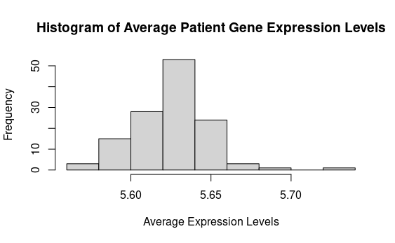

```r
hist(patient.means, main=paste("Histogram of Average Patient Gene Expression Levels"), xlab ="Average Expression Levels")
```

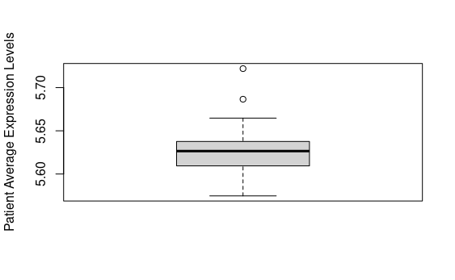

```r
boxplot(patient.means, ylab="Patient Average Expression Levels")
```

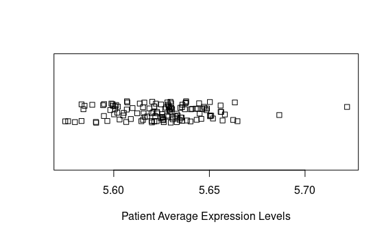

```r
stripchart(patient.means,method = "jitter", xlab="Patient Average Expression Levels")
```

```r
stem(patient.means)
```

```
  The decimal point is 2 digit(s) to the left of the |

  557 | 56
  558 | 033459
  559 | 114557899
  560 | 001112235577779
  561 | 02445566689
  562 | 000011112223355555666778889999
  563 | 00000011123333455566678888
  564 | 00133455667889
  565 | 0001266678
  566 | 235
  567 |
  568 | 7
  569 |
  570 |
  571 |
  572 | 2
```

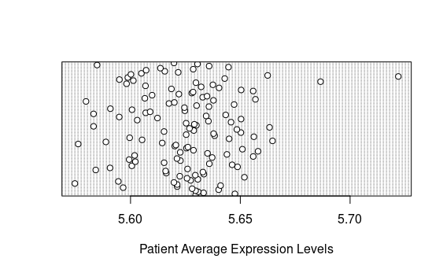

```r
dotchart(patient.means, xlab="Patient Average Expression Levels")
```

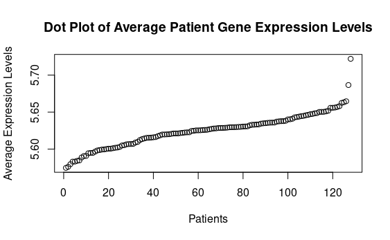

```r
plot(sort(patient.means),type="p", main="Dot Plot of Average Patient Gene Expression Levels", ylab = "Average Expression Levels", xlab="Patients")
```

**b. Calculate average gene expression levels for each gene. Plot them using: i. Histogram ii. Boxplot iii. sorted in the ascending order**

```r
# gene.means <- sapply(1:12625, function(i) mean(t(geneEx)[,i]))
gene.means <- rowMeans(geneEx)
#preview
gene.means[1:10]
```

```
  1000_at   1001_at 1002_f_at 1003_s_at   1004_at   1005_at   1006_at 1007_s_at 1008_f_at   1009_at
 7.548189  5.008460  3.898461  5.980585  5.815370  9.022764  3.650952  7.301389  8.805146  9.287179
```